# 演算法 4：常模

這是六份演算法教學的第四份。 03_linking 把分數換到 D。 這一份用 D 做常模：每個月齡的分數分布，和每個孩子在同齡孩子裡的位置（同齡 z）。

你會學到：

- 為什麼先篩掉「很多孩子擠在最低分」的波次，常模的月齡範圍怎麼定。
- sinh-arcsinh（shash）分布：四個參數各管什麼。
- 四個參數怎麼隨月齡變（多項式），怎麼用最大概似估計。
- 常模表的百分位、同齡 z 和百分等級怎麼從四個參數算出來。

你需要：

- R 和 kits 0.24.2，以及 dplyr、tidyr、purrr、tibble、ggplot2。
- 知道 `kits_convert()` 換算後的分數（03_linking）。
- 看 RTMB 怎麼寫 shash 的概似時，讀 kits 的模型 的第 8 節；這裡不重複。

每一節都照同樣的順序走：

1. 這一步要做什麼（白話）。
2. 公式：排好的數學式，下面是同一條式子的 LaTeX，按一下就能複製。
3. 用示範資料一小段一小段手算。
4. 用 kits 的兩層函數再算一次：`kits_` 的步驟（會檢查、會記下設定）和 `algo_` 的積木（只有算法）。 每次都用 `identical()` 對答案；只有運算的順序或方法不同時，才用 `all.equal()` 或最大差距，並寫出容許誤差。
5. 套件裡的教學程式在哪一段，便宜的就直接跑。

## 0 準備

### 0.1 這個算法有幾步

常模在 kits 裡是兩個算法：先篩波次、定月齡（`"norm_screen"`），再配 shash（`"norms"`）。

```r
kits_algorithm("norm_screen")
```

```
#> <kits_algorithm> norm_screen: screening the waves of a norm (scores piled at the floor) and the ages of the norm
#> Steps:
#>   1. Floor share of each cohort x wave w (D to 3 decimals)
#>        floor_pct_w = round(100 × #{p ∈ w : D_p = min_{q∈w} D_q} / n_w, 1)
#>   2. Leave out the waves piled at the floor (default cut = 20)
#>        wave w left out of the norms if floor_pct_w ≥ cut
#>   3. Age range of the norms, in steps of by (0.5 month)
#>        ages = by ⌊Q_0.01(age | first wave) / by⌋, ..., by ⌈Q_0.99(age | last wave) / by⌉
#> Components:
#>   screen <- D |> kits_norm_screen(wave_m, cohort)
#>   kits_norm_ages(age_m[screen$normed], wave_m[screen$normed])   # then kits_norms()
#>   inside: floor_shares()
#> References:
#>   Lenhard, W., & Lenhard, A. (2021). Educational and Psychological Measurement, 81, 229-261.
#>   kits: the rule of this package; see ?"kits-package".
#> Read more:
#>   tutorial_algorithms/04_norms.html
#>   system.file("scripts", "norm_screen.R", package = "kits"), parts: screen, ages
```

```r
kits_algorithm("norms")
```

```
#> <kits_algorithm> norms: a continuous norm: the sinh-arcsinh (shash) distribution by maximum likelihood
#> Steps:
#>   1. Age, transformed and standardised (age_x = sqrt by default)
#>        x = (age_x(age) − m) / s
#>   2. Four polynomials in x (degrees = their top powers)
#>        μ(x) = Σ_j c_j^(μ) x^j;  log σ(x), ε(x), log δ(x) the same way
#>   3. shash density; -log L minimised by nlminb with the gradient and Hessian of RTMB
#>        log f = log δ − log σ + log cosh w − ½ log(2π(1 + u²)) − ½ sinh² w,  w = δ asinh u + ε
#>   4. Bounds as in cNORM, and several starts of delta; u = (D - mu) / sigma
#>        log σ, ε ∈ [−10, 10],  log δ ∈ [−2, 2];  one fit per δ_0, the best kept
#>   5. Same-age z and percentile rank
#>        z = sinh(δ asinh((D − μ) / σ) + ε),  PR = 100 Φ(z)
#>   6. Percentile curves (columns P3, P5, ...)
#>        P_q = μ + σ sinh((asinh(Φ⁻¹(q / 100)) − ε) / δ)
#> Components:
#>   kits_norm_data(D, age_m, ages) |> kits_norm_fit() |> kits_norm_table()  # = kits_norms()
#>   kits_norm_z(D, age_m, norm)                                # z from the norm table
#>   fit <- algo_shash(sqrt(age_m), D)                          # x = transformed age
#>   fit |> algo_shash_z(sqrt(age_m), D)                        # z at the exact age
#>   inside: best_shash_fit(), shash_quantile(), shash_z()
#> References:
#>   Jones, M. C., & Pewsey, A. (2009). Sinh-arcsinh distributions. Biometrika, 96, 761-780.
#>   Lenhard, W., & Lenhard, A. (2021). Educational and Psychological Measurement, 81, 229-261.
#>   Kristensen, K., Nielsen, A., Berg, C. W., Skaug, H., & Bell, B. M. (2016). J. Stat. Softw., 70(5).
#> Read more:
#>   tutorial_algorithms/04_norms.html
#>   system.file("scripts", "norms.R", package = "kits"), parts: data, fit, table, z, by
```

`"norms"` 的 `Components` 第三行是 `algo_` 的積木；它們實際的寫法是 `algo_shash(x, D)`，`x` 是轉換過的月齡（例如 `sqrt(age_m)`），再接 `algo_shash_z(x, D)`（第 5、7 節）。

### 0.2 示範資料：D 分數

示範資料是模擬的（`?kitm03`），沒有真實孩子的資料。 `kitm03` 的一個世代從 3 個月追到 72 個月，共 9 個波次。 語言的分數接到 D，用語言和動作的錨題（03_linking 第 5 節）。 常模不需要連結誤差，所以這裡不重抽（`n_boot = 0`）。

```r
lan03 <- filter(kitm03$responses, domain == "lan")
motor03 <- filter(kitm03$responses, domain == "motor")
item03 <- kits_item(lan03, scale = "lan M03")
item_motor <- kits_item(motor03, scale = "motor M03")
d_link <- kits_linking(list(lan = item03, motor = item_motor), kitm03$anchors)
```

每個人次的波次、月齡、性別用 `persons` 接上：

```r
persons03 <- distinct(lan03, visit_id, cohort, wave_m, age_m, sex)
lan <- lan03 |>
  kits_subj(item03, persons = persons03) |>
  kits_convert(d_link)
as_tibble(lan) |>
  summarise(n = n(), median_D = round(median(theta), 1), .by = wave_m)
```

```
#> # A tibble: 9 × 3
#>   wave_m     n median_D
#>    <dbl> <int>    <dbl>
#> 1      3   434     28.3
#> 2      6   441     34.3
#> 3     12   447     46.7
#> 4     18   461     57.4
#> 5     24   456     66.8
#> 6     36   433     77
#> 7     48   439     83.7
#> 8     60   449     90.6
#> 9     72   444     94
```

### 0.3 小工具

教學程式是套件裡的 `.R` 檔，每一段用 `# ==== part: 名字 ====` 開頭。 `show_part()` 只印其中一段：從這一行印到下一個 `# ====` 之前。

```r
read_part <- function(file, part) {
  code <- readLines(system.file("scripts", file, package = "kits"))
  start <- grep(paste0("# ==== part: ", part, " ===="), code, fixed = TRUE)
  if (length(start) != 1) stop("no part ", part, " in ", file)
  heads <- grep("^# ====", code)
  end <- c(heads[heads > start], length(code) + 1)[1] - 1
  code[start:end]
}
```

````r
show_part <- function(file, part) cat("```r", read_part(file, part), "```", sep = "\n")
run_script <- function(file) {
  env <- new.env(parent = globalenv())
  path <- system.file("scripts", file, package = "kits")
  printed <- capture.output(suppressMessages(sys.source(path, envir = env)))
  env
}
````

常模表記下呼叫它的那一行字（`attr(, "info")$call`）。 一步一步接起來的表和一次呼叫的表，只有這一行字不同；`without_call()` 拿掉它：

```r
without_call <- function(x) {
  attr(x, "info")$call <- NULL
  x
}
```

## 1 篩掉擠在最低分的波次

### 1.1 這一步要做什麼

很多孩子擠在最低分時，分數分不出誰落後。 百分位曲線也會被拉平，分布不連續，配起來不穩定。 常模最重要的用處（找出落後的孩子）就沒了。 所以先算每個波次有幾 % 的孩子在最低分，太多的波次不放進常模。

### 1.2 公式

$$\mathit{floor\_pct}_w = \operatorname{round}\Big(100\cdot\frac{\#\{p \in w : D_p = \min_{q \in w} D_q\}}{n_w},\ 1\Big);
\qquad w \text{ left out if } \mathit{floor\_pct}_w \ge \mathit{cut}$$

```latex
\mathit{floor\_pct}_w = \operatorname{round}\Big(100\cdot\frac{\#\{p \in w : D_p = \min_{q \in w} D_q\}}{n_w},\ 1\Big);
\qquad w \text{ left out if } \mathit{floor\_pct}_w \ge \mathit{cut}
```

- $w$ 是一個（世代 ×）波次；$n_w$ 是這個波次 D 有限的人次。
- D 先取到小數點下 3 位，避免同樣的最低分因為浮點誤差被當成不同。
- 百分比先取到小數點下 1 位，再和 $\mathit{cut}$（預設 20）比。
- 擠在最高分（天花板）的波次仍然放進常模。

### 1.3 手算

```r
hand_waves <- as_tibble(lan) |>
  transmute(D = round(theta, 3), wave_m, cohort) |>
  filter(is.finite(D), !is.na(wave_m)) |>
  summarise(n = n(), floor_pct = round(100 * mean(D == min(D)), 1),
            .by = c(cohort, wave_m)) |>
  mutate(normed = floor_pct < 20) |>
  arrange(cohort, wave_m)
hand_waves
```

```
#> # A tibble: 9 × 5
#>   cohort wave_m     n floor_pct normed
#>   <chr>   <dbl> <int>     <dbl> <lgl>
#> 1 M03         3   434      23   FALSE
#> 2 M03         6   441       7.9 TRUE
#> 3 M03        12   447       1.1 TRUE
#> 4 M03        18   461       0.2 TRUE
#> 5 M03        24   456       0.2 TRUE
#> 6 M03        36   433       0.2 TRUE
#> 7 M03        48   439       0.2 TRUE
#> 8 M03        60   449       0.2 TRUE
#> 9 M03        72   444       0.2 TRUE
```

3 個月有 23% 的孩子在最低分，超過 20%，所以不放進常模。 每個人次跟著自己的波次：

```r
kept_waves <- filter(hand_waves, normed)$wave_m
hand_normed <- is.finite(lan$theta) & lan$wave_m %in% kept_waves
table(hand_normed)
```

```
#> hand_normed
#> FALSE  TRUE
#>   434  3570
```

### 1.4 用 kits

`kits_norm_screen()` 直接吃換算好的分數表（`theta`、`wave_m`、`cohort` 都在裡面）：

```r
screen <- kits_norm_screen(lan)
c(floor_pct = identical(screen$waves$floor_pct, hand_waves$floor_pct),
  waves = identical(screen$waves$normed, hand_waves$normed),
  normed = identical(screen$normed, hand_normed))
```

```
#> floor_pct     waves    normed
#>      TRUE      TRUE      TRUE
```

也可以給三個向量，結果相同：

```r
screen_v <- kits_norm_screen(lan$theta, lan$wave_m, cohort = lan$cohort)
identical(screen_v$normed, screen$normed)
```

```
#> [1] TRUE
```

這一步沒有 `algo_` 的積木：它只是計數。

### 1.5 讀這個百分比時

- 一個波次有幾個作答組合時，每個組合的最低原始分對到不同的 D，所以這個百分比會低估。 這時可以分開看每個作答組合。
- 兩個世代有同一個波次時（例如 36 個月），`cohort` 讓兩個世代分開算。
- 百分比先取到小數點下 1 位：例如 19.96% 算成 20.0%，`cut = 20` 時不放進常模。

## 2 常模的月齡

### 2.1 這一步要做什麼

常模表一列是一個月齡，每半個月一列。 少數特別小或特別大的孩子，不該把常模拉到幾乎沒有資料的月齡。 所以範圍從第一個波次月齡的 1 百分位，到最後一個波次月齡的 99 百分位，兩端往外取到半個月。

### 2.2 公式

$$\text{ages} = \mathit{by}\lfloor Q_{p_1}(\text{age}\mid\text{first wave})/\mathit{by}\rfloor,\ \dots,\
\mathit{by}\lceil Q_{p_2}(\text{age}\mid\text{last wave})/\mathit{by}\rceil$$

```latex
\text{ages} = \mathit{by}\lfloor Q_{p_1}(\text{age}\mid\text{first wave})/\mathit{by}\rfloor,\ \dots,\
\mathit{by}\lceil Q_{p_2}(\text{age}\mid\text{last wave})/\mathit{by}\rceil
```

- $Q$ 是 R 的 `quantile()`（type 7）；$p_1 = 0.01$、$p_2 = 0.99$；$\mathit{by} = 0.5$ 個月。
- 第一個、最後一個波次是放進常模的波次裡 `wave_m` 最小、最大的。

### 2.3 手算

```r
use <- lan[screen$normed, ]
first <- use$age_m[use$wave_m == min(use$wave_m)]
last <- use$age_m[use$wave_m == max(use$wave_m)]
lo <- floor(quantile(first, 0.01, names = FALSE) / 0.5) * 0.5
hi <- ceiling(quantile(last, 0.99, names = FALSE) / 0.5) * 0.5
c(lo = lo, hi = hi)
```

```
#> lo hi
#>  5 74
```

`seq()` 的最後一位可能有很小的浮點誤差，所以取到小數點下 10 位：

```r
hand_ages <- round(seq(lo, hi, by = 0.5), 10)
length(hand_ages)
```

```
#> [1] 139
```

### 2.4 用 kits

```r
ages <- kits_norm_ages(use$age_m, use$wave_m)
c(vectors = identical(ages, hand_ages), table = identical(kits_norm_ages(use), hand_ages))
```

```
#> vectors   table
#>    TRUE    TRUE
```

### 2.5 教學程式

`norm_screen.R` 的兩段就是第 1、2 節。 它的輸入是示範資料語言的 WLE（lan M03 的量尺，還沒換到 D）；換算是一條直線，所以篩出的波次一樣。

```r
show_part("norm_screen.R", "screen")
# ==== part: screen ====
# 1 The percentage of children at the lowest score of each (cohort x) wave, with D rounded to 3
#   decimals and the percentage to 1 decimal; a wave with cut % or more is left out
cut <- 20
waves <- tibble(D = round(D, 3), wave_m = wave_m, cohort = cohort) |>
  filter(is.finite(D), !is.na(wave_m)) |>
  summarise(n = n(), floor_pct = round(100 * mean(D == min(D)), 1), .by = c(cohort, wave_m)) |>
  mutate(normed = floor_pct < cut) |>
  arrange(cohort, wave_m)
waves

# 2 Each person-wave goes into the norm when its (cohort x) wave does
normed <- tibble(D = D, wave_m = wave_m, cohort = cohort) |>
  left_join(select(waves, cohort, wave_m, wave_normed = normed), by = c("cohort", "wave_m")) |>
  mutate(normed = is.finite(D) & wave_normed %in% TRUE) |>
  pull(normed)
table(normed)

show_part("norm_screen.R", "ages")
# ==== part: ages ====
# 3 The ages of the norm: from the 1st percentile of age in the first wave to the 99th in the
#   last wave, both rounded outward to half a month
in_norm <- tibble(age_m = age_m, wave_m = wave_m)[normed, ] |>
  filter(is.finite(age_m))
first_wave <- filter(in_norm, wave_m == min(wave_m))$age_m
last_wave <- filter(in_norm, wave_m == max(wave_m))$age_m
lo <- floor(quantile(first_wave, 0.01, names = FALSE) / 0.5) * 0.5
hi <- ceiling(quantile(last_wave, 0.99, names = FALSE) / 0.5) * 0.5
ages <- round(seq(lo, hi, by = 0.5), 10)
range(ages)
```

整份程式在乾淨的環境裡跑一次，再和 kits 比：

```r
env_screen <- run_script("norm_screen.R")
screen_script <- kits_norm_screen(env_screen$D, env_screen$wave_m, cohort = env_screen$cohort)
c(floor_pct = identical(env_screen$waves$floor_pct, screen_script$waves$floor_pct),
  normed = identical(env_screen$normed, screen_script$normed),
  same_waves_as_D = identical(env_screen$waves$normed, screen$waves$normed))
```

```
#>       floor_pct          normed same_waves_as_D
#>            TRUE            TRUE            TRUE
```

## 3 常模用的資料

### 3.1 這一步要做什麼

配常模只用分數和月齡都有限、月齡在 `ages` 兩端再往外 `pad` 個月（預設 1）以內的人次。 多用一點兩端外的資料，曲線在兩端比較穩。 表的月齡也不超出資料：從資料最小月齡的 `floor()` 到最大月齡的 `ceiling()`。

### 3.2 公式

$$\min(\text{ages}) - \mathit{pad} \le \text{age}_p \le \max(\text{ages}) + \mathit{pad}$$

```latex
\min(\text{ages}) - \mathit{pad} \le \text{age}_p \le \max(\text{ages}) + \mathit{pad}
```

### 3.3 手算

```r
hand_data <- tibble(d = use$theta, age_m = use$age_m) |>
  filter(is.finite(d), is.finite(age_m)) |>
  filter(age_m >= min(ages) - 1, age_m <= max(ages) + 1)
nrow(hand_data)
```

```
#> [1] 3570
```

### 3.4 用 kits

`kits_norm_data()` 是 `kits_norms()` 的第 1 步：

```r
norm_data <- kits_norm_data(use$theta, use$age_m, ages)
c(d = identical(norm_data$d, hand_data$d), age_m = identical(norm_data$age_m, hand_data$age_m),
  ages = identical(attr(norm_data, "norm")$ages, ages))
```

```
#>     d age_m  ages
#>  TRUE  TRUE  TRUE
```

`attr(norm_data, "norm")` 記下 `ages`、`pad` 和月齡的轉換（`age_x = sqrt`），下一步用。

## 4 shash 分布

### 4.1 這一步要做什麼

每個月齡的分數分布不一定對稱，偏態和尾巴的厚薄也會隨月齡改變。 sinh-arcsinh（shash）分布用四個參數描述一個分布（Jones & Pewsey, 2009）：

- $\mu$：位置；$\sigma$：尺度。
- $\varepsilon$：偏態（0 是對稱）。
- $\delta$：尾巴的厚薄（1 是常態的尾巴；小於 1 尾巴比較厚）。

$\varepsilon = 0$、$\delta = 1$ 時，就是常態分布。 分數可以是 0 或負的，不用先加一個常數。

### 4.2 公式

一個分數 $D$ 的對數密度，$u = (D - \mu)/\sigma$：

$$\log f = \log\delta - \log\sigma - \tfrac12\log 2\pi - \tfrac12\log(1+u^2)
- \tfrac12\sinh^2(\delta\operatorname{asinh}u + \varepsilon) + \log\cosh(\delta\operatorname{asinh}u + \varepsilon)$$

```latex
\log f = \log\delta - \log\sigma - \tfrac12\log 2\pi - \tfrac12\log(1+u^2)
- \tfrac12\sinh^2(\delta\operatorname{asinh}u + \varepsilon) + \log\cosh(\delta\operatorname{asinh}u + \varepsilon)
```

### 4.3 手算

照公式寫一個函數，和 $\varepsilon = 0$、$\delta = 1$ 的常態密度比：

```r
log_f <- function(D, mu, sigma, epsilon, delta) {
  u <- (D - mu) / sigma
  a <- delta * asinh(u) + epsilon
  log(delta) - log(sigma) - 0.5 * log(2 * pi) - 0.5 * log(1 + u^2) -
    0.5 * sinh(a)^2 + log(cosh(a))
}
D <- c(40, 50, 60)
all.equal(log_f(D, 50, 8, 0, 1), dnorm(D, 50, 8, log = TRUE), tolerance = 1e-12)
```

```
#> [1] TRUE
```

兩者只差運算的方法（`sinh(asinh(u))` 和 `u`），所以用 `all.equal()`（$10^{-12}$）。

### 4.4 四個參數的樣子

同樣的 $\mu = 50$、$\sigma = 8$，改 $\varepsilon$ 和 $\delta$：

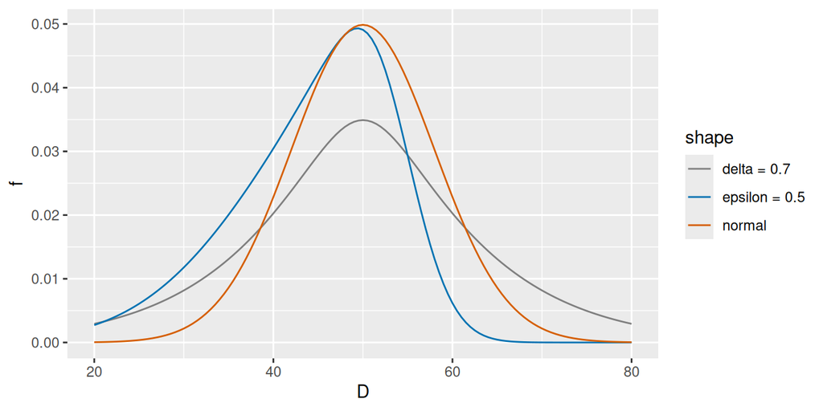

```r
shapes <- tibble(shape = c("normal", "epsilon = 0.5", "delta = 0.7"),
                 epsilon = c(0, 0.5, 0), delta = c(1, 1, 0.7))
curves <- shapes |>
  reframe(D = seq(20, 80, by = 0.5), f = exp(log_f(D, 50, 8, epsilon, delta)), .by = shape)
ggplot(curves, aes(D, f, colour = shape)) +
  geom_line() +
  scale_colour_manual(values = c("#7F7F7F", "#0072B2", "#D55E00"))
```

## 5 最大概似：`kits_norm_fit()`、`algo_shash()`

### 5.1 這一步要做什麼

常模是連續的：四個參數都是月齡的平滑函數（Lenhard & Lenhard, 2021）。 月齡先開根號、再標準化成 $x$；每個參數是 $x$ 的多項式。 $\sigma$、$\delta$ 用 log，保證是正的。 所有孩子的 $\log f$ 加起來是對數概似；找讓它最大的係數。 kits 只寫 $-\log L$，梯度和 Hessian 由 RTMB 自動微分給（RTMB 的程式見 kits 的模型 第 8 節）。

### 5.2 公式

月齡和四個多項式：

$$x = (\operatorname{age\_x}(\text{age}) - m) / s$$

```latex
x = (\operatorname{age\_x}(\text{age}) - m) / s
```

$$\mu(x) = \sum_j c^{(\mu)}_j x^j,\ \log\sigma(x) = \sum_j c^{(\sigma)}_j x^j,\ \varepsilon(x)
= \sum_j c^{(\varepsilon)}_j x^j,\ \log\delta(x) = \sum_j c^{(\delta)}_j x^j$$

```latex
\mu(x) = \sum_j c^{(\mu)}_j x^j,\ \log\sigma(x) = \sum_j c^{(\sigma)}_j x^j,\ \varepsilon(x)
= \sum_j c^{(\varepsilon)}_j x^j,\ \log\delta(x) = \sum_j c^{(\delta)}_j x^j
```

界限（和 cNORM 的 `cnorm.shash()` 相同）：

$$\log\sigma,\ \varepsilon \in [-10, 10],\quad \log\delta \in [-2, 2]$$

```latex
\log\sigma,\ \varepsilon \in [-10, 10],\quad \log\delta \in [-2, 2]
```

- `age_x` 預設是 `sqrt`；$m$、$s$ 是資料裡 $\sqrt{\text{age}}$ 的平均和 SD。
- `degrees = c(5, 4, 3, 2)` 是四個多項式的最高次數（給 KIT 約 12 個波次）；2 到 5 個波次用低一點的，例如 `c(3, 2, 1, 1)`。
- 係數共 $6 + 5 + 4 + 3 = 18$ 個。
- 起始值：$\mu$ 是 D 的平均，$\log\sigma$ 是 $\log\mathrm{SD}(D)$，$\varepsilon = 0$，$\log\delta = \log\delta_0$。
- 概似有多個局部解，所以每個 $\delta_0$（`delta_starts = c(0.5, 1, 1.5, 2)`）各配一次，留下 $-\log L$ 最小的。
- 最佳化：`nlminb()`，用 RTMB 的梯度和 Hessian。cNORM 用 `optim()` 的 L-BFGS-B；兩者走到同一個解，數字差到約 $10^{-6}$。
- 收斂：和 `kits_item()` 相同；不在界上的係數，最大 |梯度| $\le 10^{-4}$，而且它們的 Hessian 正定。沒收斂時，從停下的地方再走（最多 3 次）。

### 5.3 用 kits

`kits_norm_fit()` 是第 2 步，四個起始值各配一次（約 4 秒）：

```r
fit <- kits_norm_fit(norm_data)
fit
```

```
#> <kits_norm_fit> shash by maximum likelihood: 3570 person-waves, degrees 5, 4, 3, 2, -log L = 12011.97195
#>   converged (nlminb code 0: relative convergence (4); max |gradient| < 1e-4, Hessian of the free coefficients positive definite)
#> Next: kits_norm_table(x).
```

`algo_shash()` 是一個起始值的配適。 四個起始值各跑一次，留下最好的，就是 `kits_norm_fit()` 的模型：

```r
x_age <- sqrt(norm_data$age_m)
fits <- map(c(0.5, 1, 1.5, 2), \(d0) algo_shash(x_age, norm_data$d, delta0 = d0))
best <- fits[[which.min(map_dbl(fits, "value"))]]
map_dbl(fits, "value")
```

```
#> [1] 12011.97 12011.97 12011.97 12129.70
```

```r
identical(best, fit$model)
```

```
#> [1] TRUE
```

### 5.4 手算：對數概似

用 `best` 的係數，每個孩子的月齡算四個參數，照 4.2 節的 $\log f$ 加起來。 先是標準化的月齡和多項式：

```r
x <- (x_age - best$age_mean) / best$age_sd
poly <- function(cf, x) drop(outer(x, seq_along(cf) - 1, "^") %*% cf)
keep_in <- function(v, bound) pmin(pmax(v, -bound), bound)
c(m = identical(best$age_mean, mean(x_age)), s = identical(best$age_sd, sd(x_age)))
```

```
#>    m    s
#> TRUE TRUE
```

```r
mu <- poly(best$mu_est, x)
sigma <- exp(keep_in(poly(best$sigma_est, x), 10))
epsilon <- keep_in(poly(best$epsilon_est, x), 10)
delta <- exp(keep_in(poly(best$delta_est, x), 2))
neg_loglik <- -sum(log_f(norm_data$d, mu, sigma, epsilon, delta))
c(by_hand = neg_loglik, kits = fit$model$value)
```

```
#>  by_hand     kits
#> 12011.97 12011.97
```

```r
all.equal(neg_loglik, fit$model$value, tolerance = 1e-12)
```

```
#> [1] TRUE
```

kits 的 $\log\cosh$ 和 $\log(1 + u^2)$ 用比較穩的寫法（`log1p()`），所以只到 $10^{-12}$ 以內相同。

### 5.5 教學程式

`norms.R` 的 `fit` 段：`nll()` 就是 $-\sum\log f$，`clamp()` 是可以微分的界限。

```r
show_part("norms.R", "fit")
# ==== part: fit ====
# 2 Each parameter is a polynomial in x = (age_x(age) - m) / s. The shash log density, with
#   u = (D - mu) / sigma and a = delta asinh(u) + epsilon:
#   log f = log delta - log sigma - log(2 pi) / 2 - log(1 + u^2) / 2 - sinh(a)^2 / 2 + log cosh(a)
m <- mean(age_x(norm_data$age_m))
s <- sd(age_x(norm_data$age_m))
xd <- (age_x(norm_data$age_m) - m) / s
X_of <- function(degree) outer(xd, 0:degree, "^")

# As in cNORM, log sigma and epsilon stay within -10..10 and log delta within -2..2 at every point
clamp <- function(v, bound) (abs(v + bound) - abs(v - bound)) / 2   # pmin(pmax(v, -b), b)
logcosh <- function(a) abs(a) + log1p(exp(-2 * abs(a))) - log(2)
nll <- function(par) {
  mu <- drop(X_of(degrees[1]) %*% par$c_mu)
  sigma <- exp(clamp(drop(X_of(degrees[2]) %*% par$c_sigma), 10))
  epsilon <- clamp(drop(X_of(degrees[3]) %*% par$c_epsilon), 10)
  delta <- exp(clamp(drop(X_of(degrees[4]) %*% par$c_delta), 2))
  u <- (norm_data$D - mu) / sigma
  a <- delta * asinh(u) + epsilon
  -sum(log(delta) - log(sigma) - 0.5 * log(2 * pi) - 0.5 * log1p(u^2) - 0.5 * sinh(a)^2 +
         logcosh(a))
}

# 3 One fit per start of delta, by nlminb with the RTMB gradient and Hessian and the same
#   bounds; keep the largest likelihood
lower <- c(rep(-Inf, degrees[1] + 1), rep(-10, degrees[2] + 1), rep(-10, degrees[3] + 1),
           rep(-2, degrees[4] + 1))
fit_from <- function(d0) {
  start <- list(c_mu = c(mean(norm_data$D), rep(0, degrees[1])),
                c_sigma = c(log(sd(norm_data$D)), rep(0, degrees[2])),
                c_epsilon = rep(0, degrees[3] + 1), c_delta = c(log(d0), rep(0, degrees[4])))
  obj <- MakeADFun(nll, start, silent = TRUE)
  nlminb(obj$par, obj$fn, obj$gr, obj$he, lower = lower, upper = -lower)
}
fits <- map(delta_starts, fit_from)
best <- fits[[which.min(map_dbl(fits, "objective"))]]
coef_of <- split(unname(best$par), rep(c("c_mu", "c_sigma", "c_epsilon", "c_delta"), degrees + 1))
coef_of
```

## 6 常模表：`kits_norm_table()`

### 6.1 這一步要做什麼

有了係數，就能在每個月齡（`ages`）算四個參數，夾在和配適時一樣的界限內。 再從四個參數算百分位：第 $q$ 百分位是同齡孩子有 $q$% 低於它的分數。

### 6.2 公式

$$P_q = \mu + \sigma \sinh\!\big((\operatorname{asinh}(\Phi^{-1}(q/100)) - \varepsilon)/\delta\big)$$

```latex
P_q = \mu + \sigma \sinh\!\big((\operatorname{asinh}(\Phi^{-1}(q/100)) - \varepsilon)/\delta\big)
```

- $\Phi^{-1}$ 是標準常態的分位數（`qnorm()`）。
- 預設的百分位是 3、5、10、15、25、50、75、85、90、95、97（`NORM_PCT`）。

### 6.3 手算

每個月齡的四個參數：

```r
x_tab <- (sqrt(ages) - best$age_mean) / best$age_sd
hand_table <- tibble(age_m = ages, mu = poly(best$mu_est, x_tab),
                     sigma = exp(keep_in(poly(best$sigma_est, x_tab), 10)),
                     epsilon = keep_in(poly(best$epsilon_est, x_tab), 10),
                     delta = exp(keep_in(poly(best$delta_est, x_tab), 2)))
```

第 10、50、90 百分位：

```r
P_q <- function(q, t) t$mu + t$sigma * sinh((asinh(qnorm(q / 100)) - t$epsilon) / t$delta)
hand_table <- mutate(hand_table, P10 = P_q(10, hand_table), P50 = P_q(50, hand_table),
                     P90 = P_q(90, hand_table))
filter(hand_table, age_m %in% c(6, 12, 24, 48, 72))
```

```
#> # A tibble: 5 × 8
#>   age_m    mu sigma epsilon delta   P10   P50   P90
#>   <dbl> <dbl> <dbl>   <dbl> <dbl> <dbl> <dbl> <dbl>
#> 1     6  36.4  3.89  0.410  0.877  26.3  34.5  39.6
#> 2    12  46.9  4.76  0.0653 0.857  38.6  46.6  53.8
#> 3    24  65.4  6.51 -0.0872 0.864  56.3  66.0  76.9
#> 4    48  83.4  7.11 -0.0444 0.945  74.1  83.7  93.8
#> 5    72  93.2  7.60 -0.172  1.08   86.1  94.4 104.
```

### 6.4 用 kits

`kits_norm_table()` 是第 3 步：

```r
norm_steps <- kits_norm_table(fit)
cols <- c("age_m", "mu", "sigma", "epsilon", "delta", "P10", "P50", "P90")
map_lgl(set_names(cols), \(v) identical(norm_steps[[v]], hand_table[[v]]))
```

```
#>   age_m      mu   sigma epsilon   delta     P10     P50     P90
#>    TRUE    TRUE    TRUE    TRUE    TRUE    TRUE    TRUE    TRUE
```

三步接起來，就是 `kits_norms()`；兩者只差記下來的那一行呼叫：

```r
norm <- kits_norms(use$theta, use$age_m, ages)
identical(without_call(norm), without_call(norm_steps))
```

```
#> [1] TRUE
```

`kits_norms(use, ages)` 直接吃分數表也可以：它再記下量尺（`"D"`），之後 `kits_norm_z()` 會檢查分數和常模在同一條量尺上。 `summary(norm)` 列出常模的檢查：收斂、係數是否碰到界限、最大的 $\delta$、各月齡十分位的同齡 z。

```r
summary(norm)
```

```
#> <kits_norms> ages 5 to 74 months (139 rows); scale: (not recorded)
#> Diagnostics:
#> status  check                                            value  message
#> ok      optimizer convergence                                0  converged (nlminb code 0: relative convergence (4); max |gradient| < 1e-4, Hessian of the free coefficients positive definite)
#> ok      max |gradient|                                1.56e-09  largest |d(-log L) / d coefficient| over the free coefficients (tolerance 1e-4)
#> ok      coefficients at their limits                         0  none
#> ok      max delta                                         1.09  largest tail parameter over the ages
#> ok      same-age z: max |mean| by age decile             0.132  largest at ages (17.8,23.3]
#> ok      same-age z: SD furthest from 1 by age decile      1.14  at ages (23.3,25.1]
```

### 6.5 畫出來

灰色的點是孩子，藍色是 P50，橘色是 P10 和 P90：

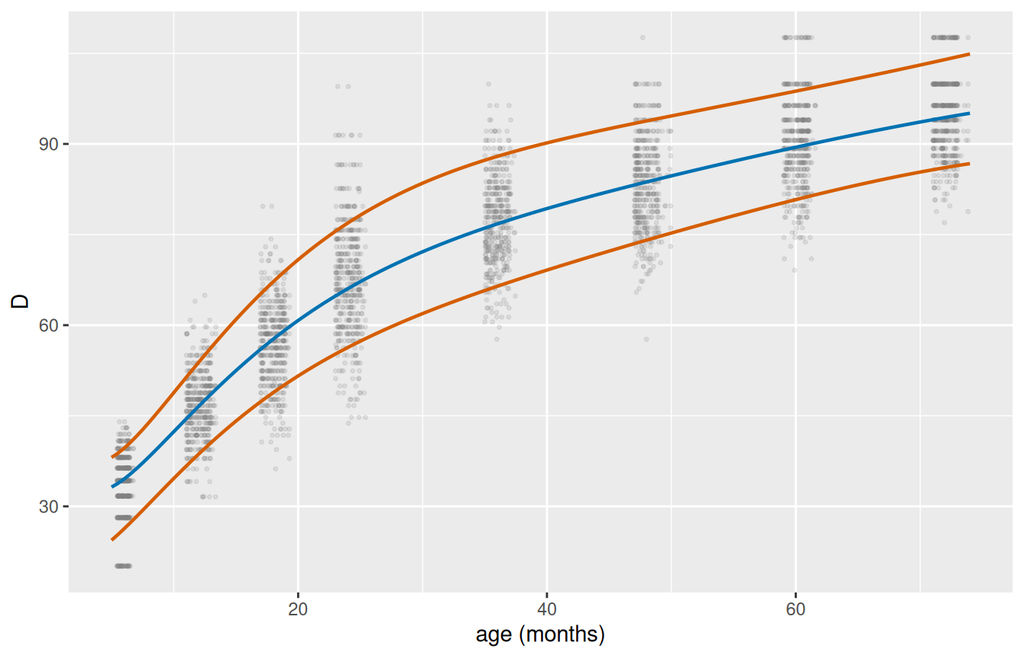

```r
curves <- as_tibble(norm) |>
  select(age_m, P10, P50, P90) |>
  pivot_longer(-age_m, names_to = "percentile", values_to = "D")
ggplot(curves, aes(age_m, D)) +
  geom_point(data = norm_data, aes(age_m, d), colour = "#7F7F7F", alpha = 0.15, size = 0.6) +
  geom_line(aes(group = percentile, colour = percentile == "P50"), linewidth = 0.8) +
  scale_colour_manual(values = c(`FALSE` = "#D55E00", `TRUE` = "#0072B2"), guide = "none") +
  labs(x = "age (months)", y = "D")
```

### 6.6 教學程式

`norms.R` 的 `data` 段和 `table` 段：

```r
show_part("norms.R", "data")
# ==== part: data ====
# 1 The data within the ages (plus pad); the table keeps the ages within the data
norm_data <- tibble(D = D, age_m = age_m) |>
  filter(is.finite(D), is.finite(age_m)) |>
  filter(age_m >= min(ages) - pad, age_m <= max(ages) + pad)
ages <- ages[ages >= floor(min(norm_data$age_m)) & ages <= ceiling(max(norm_data$age_m))]
norm_data

show_part("norms.R", "table")
# ==== part: table ====
# 4 mu, sigma, epsilon, delta at each age: the polynomials, kept within the limits of the fit
x <- (age_x(ages) - m) / s
poly_x <- function(coef) drop(outer(x, seq_along(coef) - 1, "^") %*% coef)
keep_in <- function(v, bound) pmin(pmax(v, -bound), bound)
norm <- tibble(age_m = ages,
               mu = poly_x(coef_of$c_mu),
               sigma = exp(keep_in(poly_x(coef_of$c_sigma), 10)),
               epsilon = keep_in(poly_x(coef_of$c_epsilon), 10),
               delta = exp(keep_in(poly_x(coef_of$c_delta), 2)))

# 5 Percentiles: P_q = mu + sigma sinh((asinh(qnorm(q / 100)) - epsilon) / delta)
for (q in pct) {
  norm[[paste0("P", q)]] <- with(norm, mu + sigma * sinh((asinh(qnorm(q / 100)) - epsilon) / delta))
}
norm
```

## 7 同齡 z：`kits_norm_z()`、`algo_shash_z()`

### 7.1 這一步要做什麼

同齡 z 說一個孩子在同齡孩子裡的位置：0 是中間，$-1.28$ 大約是第 10 百分位。 它是百分位公式的反函數：把分數放回標準常態。 百分等級（PR）是 $100\,\Phi(z)$。

### 7.2 公式

$$z = \sinh\!\big(\delta\,\operatorname{asinh}((D - \mu)/\sigma) + \varepsilon\big),\qquad PR = 100\,\Phi(z)$$

```latex
z = \sinh\!\big(\delta\,\operatorname{asinh}((D - \mu)/\sigma) + \varepsilon\big),\qquad PR = 100\,\Phi(z)
```

- $\mu$、$\sigma$、$\varepsilon$、$\delta$ 是這個孩子月齡的參數。
- 孩子的月齡在常模表的兩列之間時，四個參數用線性內插。
- 常模範圍以外的月齡是 NA。
- 滿分的孩子沒有上限，所以他的 z 沒有意義；自己把它設成 NA。

### 7.3 手算

四個參數在每個孩子的月齡線性內插，再照公式：

```r
at <- function(v) approx(norm$age_m, norm[[v]], use$age_m)$y
z_hand <- sinh(at("delta") * asinh((use$theta - at("mu")) / at("sigma")) + at("epsilon"))
c(mean = mean(z_hand), sd = sd(z_hand))
```

```
#>          mean            sd
#> -0.0008781732  0.9994131207
```

### 7.4 用 kits

`kits_` 這一層：給向量得到 z；給分數表得到多了 `z`、`pct` 兩欄的表。

```r
z_kits <- kits_norm_z(use$theta, use$age_m, norm)
use_z <- use |>
  kits_norm_z(norm)
c(vector = identical(z_kits, z_hand), table = identical(use_z$z, z_hand),
  pct = identical(use_z$pct, 100 * pnorm(z_hand)))
```

```
#> vector  table    pct
#>   TRUE   TRUE   TRUE
```

每個波次的平均接近 0、SD 接近 1，表示常模配得好：

```r
as_tibble(use_z) |>
  summarise(mean = round(mean(z), 2), sd = round(sd(z), 2), .by = wave_m)
```

```
#> # A tibble: 8 × 3
#>   wave_m  mean    sd
#>    <dbl> <dbl> <dbl>
#> 1      6 -0.03  1.01
#> 2     12  0.06  0.95
#> 3     18 -0.14  0.96
#> 4     24  0.12  1.14
#> 5     36  0.02  0.87
#> 6     48 -0.06  0.98
#> 7     60  0.04  1.07
#> 8     72 -0.01  0.97
```

`algo_` 這一層：`algo_shash_z()` 直接在孩子的月齡算多項式，不經過常模表，所以不內插。

```r
z_algo <- best |>
  algo_shash_z(sqrt(use$age_m), use$theta)
max(abs(z_algo - z_kits))
```

```
#> [1] 0.004212449
```

差距是半個月一列的線性內插造成的，這裡最多約 0.0042。 在表上的月齡，兩者相同：

```r
row24 <- filter(as_tibble(norm), age_m == 24)
z24 <- algo_shash_z(best, sqrt(24), row24$P10)
c(algo = z24, qnorm = qnorm(0.10), diff = z24 - qnorm(0.10))
```

```
#>          algo         qnorm          diff
#> -1.281552e+00 -1.281552e+00  6.661338e-16
```

### 7.5 教學程式

`norms.R` 的 `z` 段：`approx()` 在常模表的兩列之間線性內插。

```r
show_part("norms.R", "z")
# ==== part: z ====
# 6 Same-age z = sinh(delta asinh((D - mu) / sigma) + epsilon), the parameters interpolated
#   between the ages of the table; PR = 100 pnorm(z); ages outside the norm get NA
at <- function(v) approx(norm$age_m, v, age_m)$y
z <- sinh(at(norm$delta) * asinh((D - at(norm$mu)) / at(norm$sigma)) + at(norm$epsilon))
summary(z)
```

整份程式在乾淨的環境裡跑一次（約 10 秒），看它自己的 `compare` 段（容許誤差 $10^{-4}$）：

```r
env_norm <- run_script("norms.R")
env_norm$diffs
```

```
#>  mu  P3 P50 P97   z
#>   0   0   0   0   0
```

`compare` 之後的 `by` 段是分性別的常模（`kits_norms(..., by = data.frame(sex = sex))`）：每一組各配一次，每個孩子放在自己這一組的曲線上。

```r
env_norm$diffs_by
```

```
#>      mu   sigma epsilon   delta       z
#>       0       0       0       0       0
```

## 8 可重現的管線

下面兩段貼進一個新的 R session，只要 `library(kits)`，就得到和這份教學完全相同的常模。 資料用 base R 的 `subset()`，不用 dplyr。

```r
library(kits)
lan03 <- subset(kitm03$responses, domain == "lan")
motor03 <- subset(kitm03$responses, domain == "motor")
item03 <- kits_item(lan03, scale = "lan M03")
item_motor <- kits_item(motor03, scale = "motor M03")
d_link <- kits_linking(list(lan = item03, motor = item_motor), kitm03$anchors)
persons03 <- unique(lan03[c("visit_id", "cohort", "wave_m", "age_m", "sex")])
lan <- lan03 |>
  kits_subj(item03, persons = persons03) |>
  kits_convert(d_link)
```

常模：一次呼叫、三步的 `kits_` 管線、`algo_` 的積木。

```r
screen <- kits_norm_screen(lan)
use <- lan[screen$normed, ]
ages <- kits_norm_ages(use)
norm <- kits_norms(use$theta, use$age_m, ages)
norm_steps <- kits_norm_data(use$theta, use$age_m, ages) |>
  kits_norm_fit() |>
  kits_norm_table()
z_algo <- algo_shash(sqrt(use$age_m), use$theta, delta0 = 0.5) |>
  algo_shash_z(sqrt(use$age_m), use$theta)
```

`algo_shash()` 只用一個起始值；$\delta_0 = 0.5$ 走到最好的解（5.3 節），所以用它就夠。 它要和 5.3 節的 `fits[[1]]`（$\delta_0 = 0.5$ 的那一次）相同。 這份教學真的開一個新的 R session（`callr::r()`）跑這兩段，再把結果帶回來比：

```r
code <- unlist(map(c("repro-data", "repro-norm"), knitr::knit_code$get))
fresh <- callr::r(function(code) {
  env <- new.env()
  eval(parse(text = code), envir = env)
  as.list(env)
}, args = list(code = code))
```

```r
c(lan = identical(fresh$lan$theta, lan$theta),
  screen = identical(fresh$screen$normed, screen$normed),
  ages = identical(fresh$ages, ages), norm = identical(fresh$norm, norm),
  steps = identical(without_call(fresh$norm_steps), without_call(norm)),
  algo = identical(fresh$z_algo, algo_shash_z(fits[[1]], sqrt(use$age_m), use$theta)))
```

```
#>    lan screen   ages   norm  steps   algo
#>   TRUE   TRUE   TRUE   TRUE   TRUE   TRUE
```

- `norm` 連記下來的呼叫都相同，因為那一行字一樣。
- 三步的管線和 `kits_norms()` 只差那一行字（`without_call()`）。
- `algo_` 的積木給同樣的係數和 z，但沒有常模表、界限的檢查和診斷。

## 9 整理

| 步驟 | 公式 | `kits_` | `algo_` | 教學程式 |
| --- | --- | --- | --- | --- |
| 篩波次 | $\mathit{floor\_pct}_w \ge \mathit{cut}$ | `kits_norm_screen()` | （計數） | `norm_screen.R` `screen` |
| 月齡 | $Q_{0.01}$、$Q_{0.99}$，取到半個月 | `kits_norm_ages()` | （分位數） | `ages` |
| 資料 | 月齡在 `ages` $\pm$ `pad` | `kits_norm_data()` | （篩選） | `norms.R` `data` |
| shash 的概似 | $\log f$，四個多項式 | `kits_norm_fit()` | `algo_shash()` | `fit` |
| 常模表 | $P_q$ | `kits_norm_table()` | （多項式） | `table` |
| 同齡 z | $z = \sinh(\delta\operatorname{asinh}u + \varepsilon)$ | `kits_norm_z()` | `algo_shash_z()` | `z` |

選 `degrees` 和讀診斷：

- 月齡範圍內至少要 $10\sum(\text{degrees} + 1)$ 個人次，不然停下來。
- 次數太高時，曲線在月齡兩端會失控；看每個波次的同齡 z 平均是不是接近 0（7.4 節）。
- 診斷也看：同齡 z 按月齡分成十等分，平均超過 0.2，或 SD 在 0.8 到 1.2 以外，就警告。

全部算完的時間：

```r
round(difftime(Sys.time(), t_start, units = "secs"))
```

```
#> Time difference of 44 secs
```

**下一步：** 05_checks：連結、常模和題目的檢查。

## 參考文獻

- Jones, M. C., & Pewsey, A. (2009). Sinh-arcsinh distributions. *Biometrika, 96*(4), 761-780. doi:10.1093/biomet/asp053
- Lenhard, W., & Lenhard, A. (2021). Improvement of norm score quality via regression-based continuous norming. *Educational and Psychological Measurement, 81*(2), 229-261. doi:10.1177/0013164420928457
- Lenhard, A., Lenhard, W., & Gary, S. (2018). *Continuous norming (cNORM)*. The Comprehensive R Archive Network. https://CRAN.R-project.org/package=cNORM
- Kristensen, K. (2026). *RTMB: R bindings for TMB* (R package version 2.0). doi:10.32614/CRAN.package.RTMB
- R Core Team (2026). *R: A language and environment for statistical computing*. R Foundation for Statistical Computing, Vienna, Austria. https://www.R-project.org/